# Analysis of TED Talks

Turkan Sevgili - BDA 503 - Fall 2017

### TED Talks Dataset

**[TED Talks](https://www.kaggle.com/rounakbanik/ted-talks/data)** dataset contains information about all audio-video recordings of TED Talks uploaded to the official TED.com website until September 21st, 2017. It contains information about all talks including number of views, number of comments, descriptions, speakers and titles.

#### Content

- *name:* The official name of the TED Talk. Includes the title and the speaker.
- *title:* The title of the talk
- *description:* A blurb of what the talk is about.
- *main_speaker:* The first named speaker of the talk.
- *speaker_occupation:* The occupation of the main speaker.
- *num_speaker:* The number of speakers in the talk.
- *duration:* The duration of the talk in seconds.
- *event:* The TED/TEDx event where the talk took place.
- *film_date:* The Unix timestamp of the filming.
- *published_date:* The Unix timestamp for the publication of the talk on TED.com
- *comments:* The number of first level comments made on the talk.
- *tags:* The themes associated with the talk.
- *languages:* The number of languages in which the talk is available.
- *ratings:* A stringified dictionary of the various ratings given to the talk (inspiring, fascinating, jaw dropping, etc.)
- *related_talks:* A list of dictionaries of recommended talks to watch next.
- *url:* The URL of the talk.
- *views:* The number of views on the talk.

#### Initial Exploratory Analysis

Ted Talks Dataset consists of 2,550 observations and 17 variables. I’ll try to find that the most viewed and most favorited Talks comments and views numbers. Also I will analyse speakers occupations,relationship between languages and views , relationship between comments and views.

```r
#Nature of rows and columns//quick review of dataset
glimpse(ted_talks)
```

```
## Observations: 2,550
## Variables: 17
## $ comments           <int> 4553, 265, 124, 200, 593, 672, 919, 46, 852...
## $ description        <chr> "Sir Ken Robinson makes an entertaining and...
## $ duration           <int> 1164, 977, 1286, 1116, 1190, 1305, 992, 119...
## $ event              <chr> "TED2006", "TED2006", "TED2006", "TED2006",...
## $ film_date          <int> 1140825600, 1140825600, 1140739200, 1140912...
## $ languages          <int> 60, 43, 26, 35, 48, 36, 31, 19, 32, 31, 27,...
## $ main_speaker       <chr> "Ken Robinson", "Al Gore", "David Pogue", "...
## $ name               <chr> "Ken Robinson: Do schools kill creativity?"...
## $ num_speaker        <int> 1, 1, 1, 1, 1, 1, 1, 1, 1, 1, 1, 1, 1, 1, 1...
## $ published_date     <int> 1151367060, 1151367060, 1151367060, 1151367...
## $ ratings            <chr> "[{'id': 7, 'name': 'Funny', 'count': 19645...
## $ related_talks      <chr> "[{'id': 865, 'hero': 'https://pe.tedcdn.co...
## $ speaker_occupation <chr> "Author/educator", "Climate advocate", "Tec...
## $ tags               <chr> "['children', 'creativity', 'culture', 'dan...
## $ title              <chr> "Do schools kill creativity?", "Averting th...
## $ url                <chr> "https://www.ted.com/talks/ken_robinson_say...
## $ views              <int> 47227110, 3200520, 1636292, 1697550, 120058...
```

```r
#Number of rows and columns
dim(ted_talks)
```

```
## [1] 2550   17
```

```r
#How many views does the most viewed TED Talk take?

max(ted_talks$views)
```

```
## [1] 47227110
```

```r
#How many comments does the most popular TED Talk take?

max(ted_talks$comments, na.rm = FALSE)
```

```
## [1] 6404
```

```r
#How many TED Talks a speaker have?
d1= ted_talks %>%group_by(main_speaker) %>%
  summarise(total_ted_talks=n())%>%
  arrange(desc(total_ted_talks))

d1
```

```
## # A tibble: 2,156 x 2
##            main_speaker total_ted_talks
##                   <chr>           <int>
##  1         Hans Rosling               9
##  2        Juan Enriquez               7
##  3        Marco Tempest               6
##  4                Rives               6
##  5           Bill Gates               5
##  6          Clay Shirky               5
##  7           Dan Ariely               5
##  8 Jacqueline Novogratz               5
##  9      Julian Treasure               5
## 10  Nicholas Negroponte               5
## # ... with 2,146 more rows
```

```r
#What are speakers occupations?
d2= ted_talks %>%group_by(speaker_occupation) %>%
  summarise(total_ted_talks=n())%>%
  arrange(desc(total_ted_talks))

d2
```

```
## # A tibble: 1,449 x 2
##    speaker_occupation total_ted_talks
##                 <chr>           <int>
##  1             Writer              45
##  2             Artist              34
##  3           Designer              34
##  4         Journalist              33
##  5       Entrepreneur              31
##  6          Architect              30
##  7           Inventor              27
##  8       Psychologist              26
##  9       Photographer              25
## 10          Filmmaker              21
## # ... with 1,439 more rows
```

```r
library(ggplot2)#visualisation

#How many speaker have 5/more than 5 TED Talks?
d3 = ted_talks %>%group_by(main_speaker) %>%
  summarise(total_ted_talks=n())%>%
  filter(total_ted_talks>=5) %>%
  arrange(desc(total_ted_talks))

d3
```

```
## # A tibble: 10 x 2
##            main_speaker total_ted_talks
##                   <chr>           <int>
##  1         Hans Rosling               9
##  2        Juan Enriquez               7
##  3        Marco Tempest               6
##  4                Rives               6
##  5           Bill Gates               5
##  6          Clay Shirky               5
##  7           Dan Ariely               5
##  8 Jacqueline Novogratz               5
##  9      Julian Treasure               5
## 10  Nicholas Negroponte               5
```

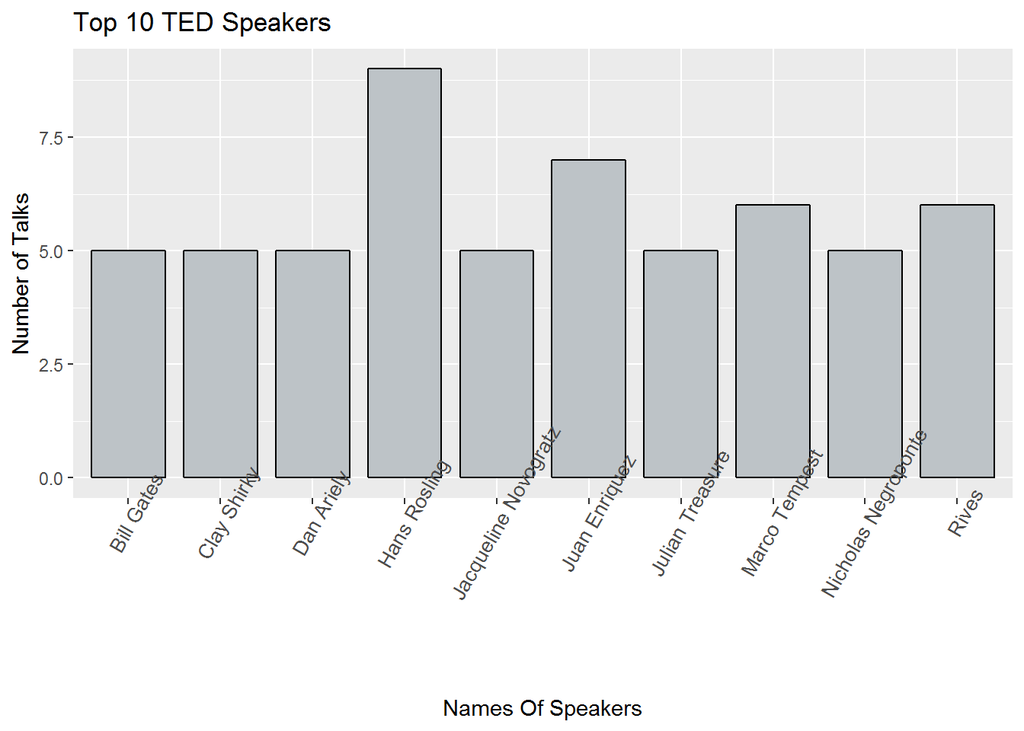

```r
#Who is Top 10 popular TED Talks Speaker?
v1 <- ggplot(data=d3, aes(x=main_speaker, y=total_ted_talks, fill=time)) +
  geom_bar(colour="black", fill="#bdc3c7", width=.8, stat="identity") +
  guides(fill=FALSE) +
  xlab("Names Of Speakers") + ylab("Number of Talks") +
  ggtitle("Top 10 TED Speakers")+
  theme(axis.text.x = element_text(angle=60, size=10))
v1
```

```r
# Which occupations are most popular amongst TED speakers?
d4= ted_talks %>%group_by(speaker_occupation) %>%
  summarise(total_ted_talks=n())%>%
  filter(total_ted_talks>=20) %>%
  arrange(desc(total_ted_talks))

d4
```

```
## # A tibble: 15 x 2
##    speaker_occupation total_ted_talks
##                 <chr>           <int>
##  1             Writer              45
##  2             Artist              34
##  3           Designer              34
##  4         Journalist              33
##  5       Entrepreneur              31
##  6          Architect              30
##  7           Inventor              27
##  8       Psychologist              26
##  9       Photographer              25
## 10          Filmmaker              21
## 11     Neuroscientist              21
## 12             Author              20
## 13          Economist              20
## 14           Educator              20
## 15         Roboticist              20
```

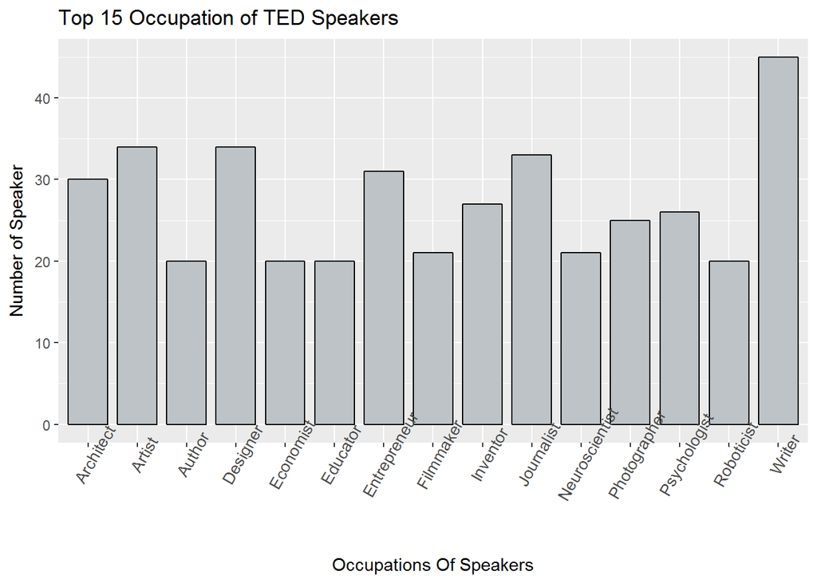

```r
#What are Top 15 Occupations of TED Speakers?
v2 <- ggplot(data=d4, aes(x=speaker_occupation, y=total_ted_talks, fill=time)) +
  geom_bar(colour="black", fill="#bdc3c7", width=.8, stat="identity") +
  guides(fill=FALSE) +
  xlab("Occupations Of Speakers") + ylab("Number of Speaker") +
  ggtitle("Top 15 Occupation of TED Speakers")+
  theme(axis.text.x = element_text(angle=60, size=10))
v2
```

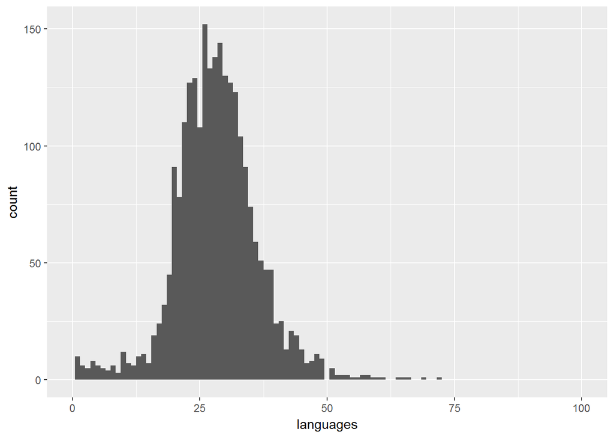

```r
#How many different languages the talk is available?

v3 <- ggplot(aes(x = languages), data = ted_talks) +
  geom_histogram(binwidth = 1) +
  scale_x_continuous(limits = c(0, 100))

v3
```

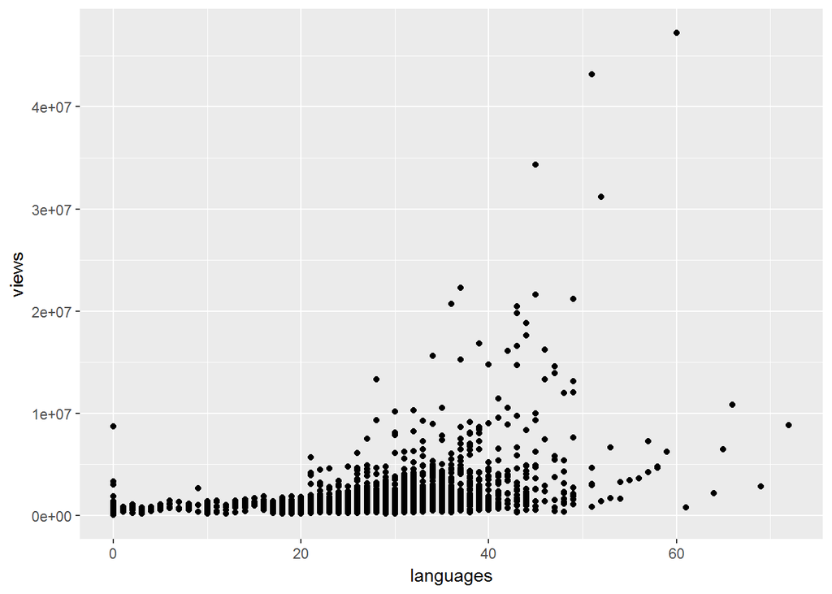

```r
#Is there any relationship between languages and views?

v4 <- ggplot(data = ted_talks, aes(x = languages, y = views)) +
  geom_point()

v4
```

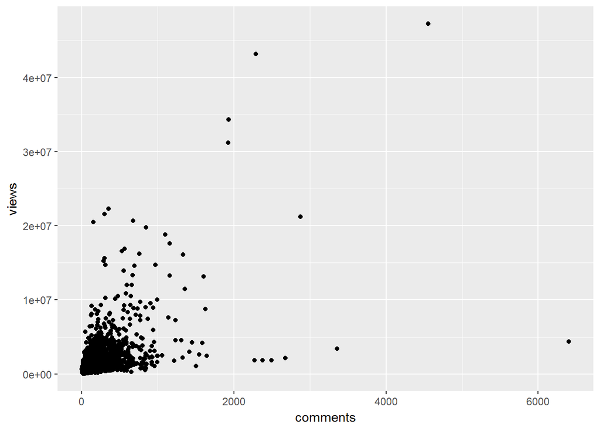

```r
#Is there any relationship between comments and views?

v5 <- ggplot(data = ted_talks, aes(x = comments, y = views)) +
  geom_point()

v5
```

#### References

Dataset;

https://www.kaggle.com/rounakbanik/ted-talks

Analysis;

https://www.kaggle.com/lpang36/analysis-of-ted-talk-ratings

https://www.rdocumentation.org/packages/dplyr/versions/0.7.3/topics/filter [https://stackoverflow.com/questions/26581410/summarizing-count-and-conditional-aggregate-functions-on-the-same-factor](https://stackoverflow.com/questions/26581410/summarizing-count-and-conditional-aggregate-functions-on-the-same-facto) https://stackoverflow.com/questions/22767893/find-number-of-rows-using-dplyr-group-by

Visualization;

http://www.cookbook-r.com/Graphs/Bar_and_line_graphs_(ggplot2)/

http://ggplot2.tidyverse.org/reference/geom_bar.html

https://plot.ly/ggplot2/geom_bar/